# Analysis of ARIMA(p,d,q) Processes

2025-08-11

# Introduction to ARIMA(p,d,q) Processes

ARIMA(p,d,q) processes extend ARMA models to handle **non-stationary** time series:

$$\Phi(L)(1-L)^d Y_t =
\Theta(L)\epsilon_t$$

Where

-**p**: Order of autoregression (AR component) -**d**: Degree of differencing (Integration component) -**q**: Order of moving average (MA component)

**Key concepts:**

-**Differencing**: Transforms non-stationary series to stationary -**Integration**: Original series is sum (integral) of stationary differences -**Unit roots**: Non-stationary behavior requiring differencing

```r
# Simulation parameters
n_obs <- 400
time_points <- 1:n_obs
```

## The Differencing Component: Understanding d

The differencing parameter d determines how many times we difference the series:

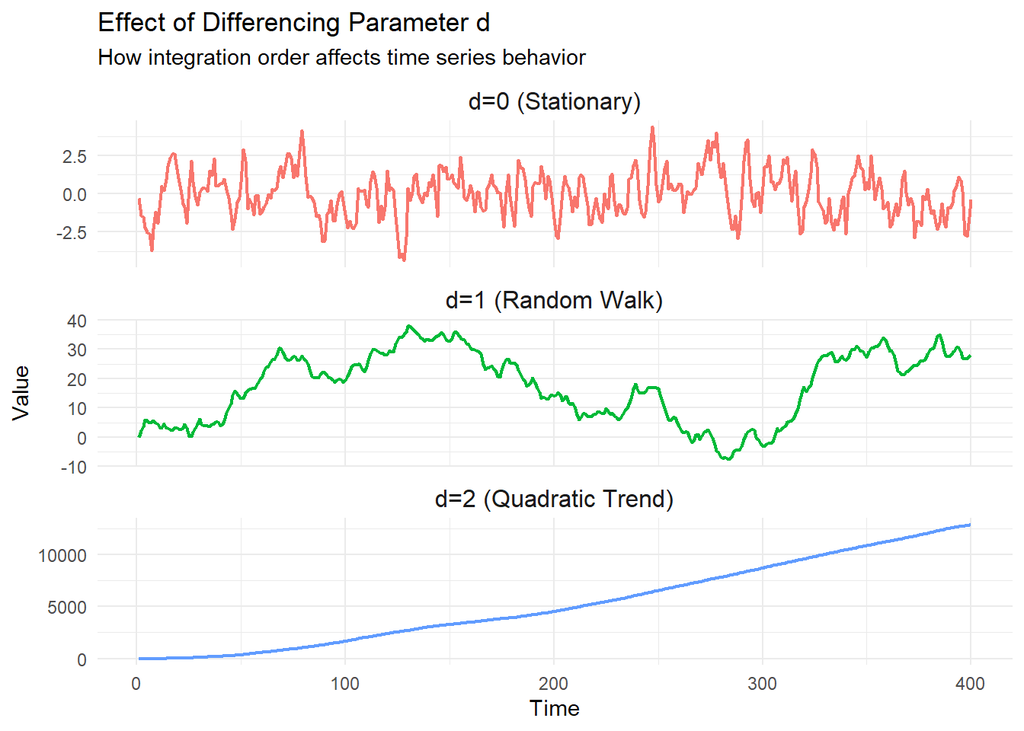

```r
# Generate different types of non-stationary processes
set.seed(123)

# d=0: Stationary ARMA(1,1)
stationary <- arima.sim(n = n_obs, list(ar = 0.7, ma = 0.3))

# d=1: Random walk with drift + ARMA structure
# Simulate ARIMA(1,1,1) by generating ARMA(1,1) differences
arma_diffs <- arima.sim(n = n_obs-1, list(ar = 0.3, ma = 0.4))
integrated_once <- cumsum(c(0, arma_diffs + 0.05))  # Adding drift

# d=2: Double integration (trend + stochastic trend)
arma_diffs2 <- arima.sim(n = n_obs-2, list(ar = 0.2, ma = 0.3))
first_diff <- cumsum(c(0, arma_diffs2 + 0.02))
integrated_twice <- cumsum(c(0, first_diff))

# Create comparison dataset
diff_data <- data.frame(
  time = rep(time_points, 3),
  value = c(stationary,
           integrated_once,
           integrated_twice),
  process = rep(c("d=0 (Stationary)", "d=1 (Random Walk)", "d=2 (Quadratic Trend)"),
                each = n_obs)
)

# Plot different integration orders
p_diff <- ggplot(diff_data, aes(x = time, y = value)) +
  geom_line(aes(color = process), size = 0.8) +
  facet_wrap(~process, scales = "free_y", ncol = 1) +
  labs(title = "Effect of Differencing Parameter d",
       subtitle = "How integration order affects time series behavior",
       x = "Time", y = "Value") +
  theme_minimal() +
  theme(legend.position = "none",
        strip.text = element_text(size = 12))
print(p_diff)
```

```r
# Show the differencing process
cat("Differencing Process:\n")
```

```
## Differencing Process:
```

```r
cat("Original d=1 series (first 10 values):", round(integrated_once[1:10], 2), "\n")
```

```
## Original d=1 series (first 10 values): 0 2.07 3.69 5.85 5.75 4.99 5.1 5.62 4.92 4.37
```

```r
cat("After 1st differencing:", round(diff(integrated_once)[1:9], 2), "\n")
```

```
## After 1st differencing: 2.07 1.63 2.16 -0.1 -0.76 0.11 0.52 -0.69 -0.56
```

```r
cat("Original d=2 series (first 10 values):", round(integrated_twice[1:10], 2), "\n")
```

```
## Original d=2 series (first 10 values): 0 0 -0.23 0.13 2.37 5.27 8.54 10.24 10.29 9.84
```

```r
cat("After 1st differencing:", round(diff(integrated_twice)[1:9], 2), "\n")
```

```
## After 1st differencing: 0 -0.23 0.36 2.24 2.9 3.27 1.7 0.05 -0.45
```

```r
cat("After 2nd differencing:", round(diff(integrated_twice, differences = 2)[1:8], 2), "\n")
```

```
## After 2nd differencing: -0.23 0.58 1.89 0.66 0.37 -1.58 -1.64 -0.5
```

## ARIMA(1,1,1) Process: The Workhorse Model

One of the most commonly used ARIMA specifications:

$$\nabla Y_t = \phi_1 \nabla Y_{t-1} +
\epsilon_t + \theta_1 \epsilon_{t-1}$$

Where $\nabla Y_t = Y_t - Y_{t-1}$ (first difference)

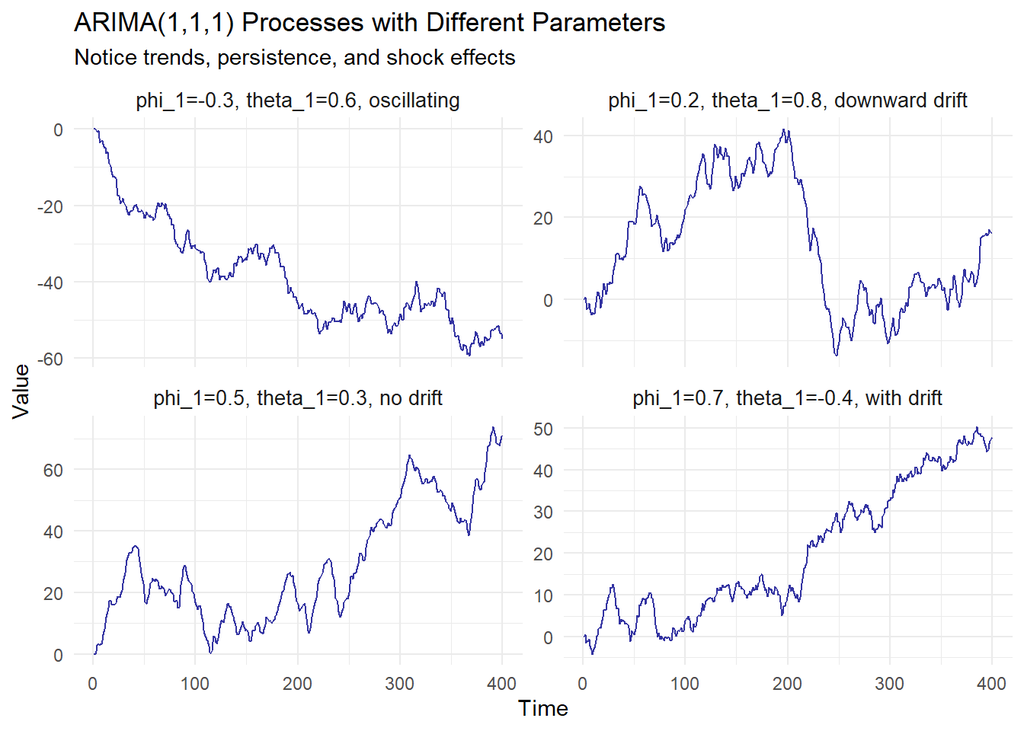

```r
# Different ARIMA(1,1,1) parameter combinations
arima111_params <- list(
  list(ar = 0.5, ma = 0.3, drift = 0, label = "phi_1=0.5, theta_1=0.3, no drift"),
  list(ar = 0.7, ma = -0.4, drift = 0.02, label = "phi_1=0.7, theta_1=-0.4, with drift"),
  list(ar = -0.3, ma = 0.6, drift = 0, label = "phi_1=-0.3, theta_1=0.6, oscillating"),
  list(ar = 0.2, ma = 0.8, drift = -0.01, label = "phi_1=0.2, theta_1=0.8, downward drift")
)

arima111_data <- data.frame()

for (i in seq_along(arima111_params)) {
  params <- arima111_params[[i]]

  # Generate ARMA process for differences
  diff_series <- arima.sim(n = n_obs-1,
                          list(ar = params$ar, ma = params$ma)) + params$drift

  # Integrate to get ARIMA(1,1,1)
  integrated_series <- cumsum(c(0, diff_series))

  temp_df <- data.frame(
    time = time_points,
    value = integrated_series,
    params = params$label,
    process = "ARIMA(1,1,1)"
  )
  arima111_data <- rbind(arima111_data, temp_df)
}

# Plot ARIMA(1,1,1) processes
p_arima111 <- ggplot(arima111_data, aes(x = time, y = value)) +
  geom_line(color = "darkblue", alpha = 0.8) +
  facet_wrap(~params, scales = "free_y", ncol = 2) +
  labs(title = "ARIMA(1,1,1) Processes with Different Parameters",
       subtitle = "Notice trends, persistence, and shock effects",
       x = "Time", y = "Value") +
  theme_minimal() +
  theme(strip.text = element_text(size = 10))

print(p_arima111)
```

## Stationarity Testing and Model Identification

Before fitting ARIMA models, we need to determine d through stationarity tests:

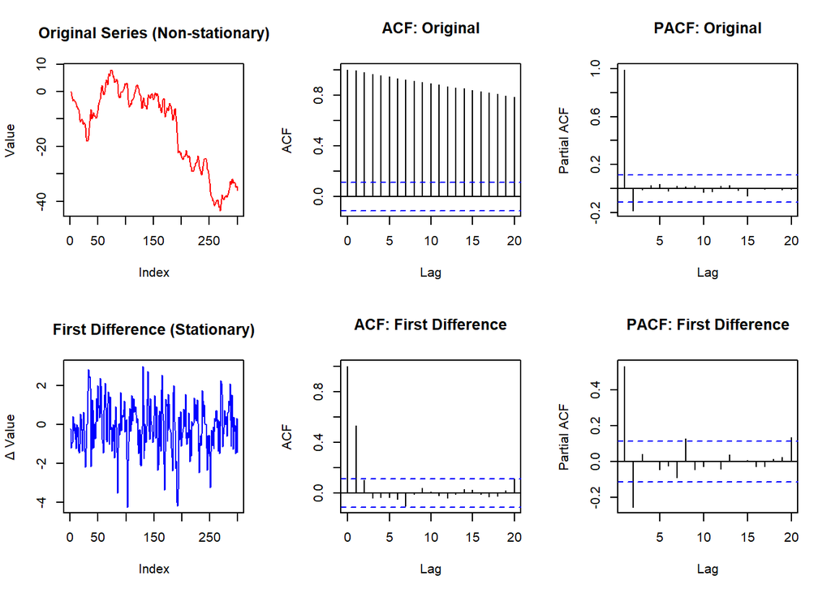

```r
# Generate a non-stationary series for analysis
set.seed(789)
test_series <- cumsum(arima.sim(n = 300, list(ar = 0.4, ma = 0.3))) +
               0.02 * (1:300)  # Add linear trend

# Function to perform ADF test (simplified version)
adf_test_simple <- function(x, lags = 1) {
  n <- length(x)
  y_lag <- x[-n]
  y_diff <- diff(x)

  # Regression: Δy_t = α + βy_{t-1} + ε_t
  model <- lm(y_diff ~ y_lag)
  beta <- coef(model)[2]
  se_beta <- summary(model)$coefficients[2, 2]
  t_stat <- beta / se_beta

  return(list(t_statistic = t_stat, p_value = 2 * pt(abs(t_stat), df = n-2, lower.tail = FALSE)))
}

# Test original series
original_adf <- adf_test_simple(test_series)
# Test first difference
diff1_adf <- adf_test_simple(diff(test_series))

# Create analysis plots
par(mfrow = c(2, 3))

# Original series
plot(test_series, type = "l", main = "Original Series (Non-stationary)",
     col = "red", ylab = "Value")
acf(test_series, main = "ACF: Original", lag.max = 20)
pacf(test_series, main = "PACF: Original", lag.max = 20)

# First difference
plot(diff(test_series), type = "l", main = "First Difference (Stationary)",
     col = "blue", ylab = "Δ Value")
acf(diff(test_series), main = "ACF: First Difference", lag.max = 20)
pacf(diff(test_series), main = "PACF: First Difference", lag.max = 20)
```

```r
par(mfrow = c(1, 1))

cat("Stationarity Test Results:\n")
```

```
## Stationarity Test Results:
```

```r
cat("Original series ADF t-statistic:", round(original_adf$t_statistic, 3), "\n")
```

```
## Original series ADF t-statistic: -0.189
```

```r
cat("First difference ADF t-statistic:", round(diff1_adf$t_statistic, 3), "\n")
```

```
## First difference ADF t-statistic: -9.473
```

```r
cat("(More negative = more likely stationary)\n\n")
```

```
## (More negative = more likely stationary)
```

```r
cat("ACF Pattern Analysis:\n")
```

```
## ACF Pattern Analysis:
```

```r
cat("- Original series: Slow decay → Non-stationary\n")
```

```
## - Original series: Slow decay → Non-stationary
```

```r
cat("- First difference: Rapid decay → Stationary\n")
```

```
## - First difference: Rapid decay → Stationary
```

```r
cat("- Conclusion: d = 1 needed\n")
```

```
## - Conclusion: d = 1 needed
```

## Key Takeaways

### **ARIMA Model Capabilities:**

1. **Non-stationarity handling**: Differencing (d) transforms trending data to stationary
2. **Flexible patterns**:
   - **p**: Captures autoregressive dependencies in differenced series
   - **d**: Handles trends and unit roots
   - **q**: Models shock effects and error correction
3. **Forecasting power**:
   - Trends are extrapolated through integration
   - Uncertainty increases appropriately over time
   - Confidence intervals reflect both parameter and forecast uncertainty
4. **Model selection**:
   - Test for optimal d using stationarity tests
   - Use AIC/BIC to select p and q
   - Consider parsimony vs. fit trade-offs

### **Practical Guidelines:**

- **d=0**: Stationary series (use ARMA)
- **d=1**: Series with stochastic trends (most common)
- **d=2**: Series with changing growth rates (rare)
- **d≥3**: Usually indicates over-differencing